# EBSmoothr Overview

# Purpose

`EBSmoothr` provides empirical-Bayes smoothers for Gaussian means problems. The package currently exposes two prior families:

- `LGP`: a one-dimensional local Gaussian-process smoother with a TMB backend.
- `Matern`: a one-dimensional or two-dimensional exact Gaussian Matern smoother built from an INLA/SPDE precision representation, with an optional INLA PC-prior backend.

At the top level, the package is organized around two collaborator-facing workflows:

- Known observation standard errors `s`: use `ebnm_LGP_generator()` or `ebnm_Matern_generator()` to build an `ebnm`-compatible fitter.
- Unknown observation standard errors: use `eb_smoother()` with `s = NULL` to learn one common observation noise SD.

`eb_smoother()` also accepts known `s`, but this overview focuses on the two main entry points above so collaborators can quickly choose the right API.

# Entry-Point Guide

## Known `s`: generator workflow

When standard errors are known and you want an `ebnm`-compatible fit, the package follows the generator pattern:

```r
library(EBSmoothr)

fit_fun <- ebnm_LGP_generator(
  LGP_setup(t = seq(0, 1, length.out = 10))
)

str(formals(fit_fun))
```

```
#> Dotted pair list of 8
#>  $ x         : symbol
#>  $ s         : symbol
#>  $ g_init    : NULL
#>  $ fix_g     : logi FALSE
#>  $ beta_fixed: NULL
#>  $ beta_prec : NULL
#>  $ fix_params: language character()
#>  $ output    : NULL
```

The resulting fitter has the usual `ebnm` signature `function(x, s, ...)` and returns an object with class `c("list", "ebnm")`.

## Unknown `s`: high-level smoothing workflow

When standard errors are unknown, `eb_smoother()` is the main entry point. It learns one common observation noise SD and returns an `eb_smoother_fit` object with compact `print()` / `summary()` methods.

```r
set.seed(1)

loc <- seq(0, 8, length.out = 100)
truth <- sin(loc) + 0.25 * cos(2 * loc)
x <- truth + rnorm(length(loc), sd = 0.2)

fit_spatial <- eb_smoother(
  x = x,
  s = NULL,
  family = "matern",
  locations = loc
)

fit_baseline <- eb_smoother(
  x = x,
  s = NULL,
  family = "constant",
  beta_prec = 0
)

fit_spatial
```

```
#> Empirical-Bayes smoother fit
#>   class: eb_smoother_fit
#>   family: matern
#>   backend: exact
#>   noise mode: estimated
#>   beta mode: empirical_bayes
#>   observations: 100
#>   fitted prior: range = 3.888, sigma = 0.7335
#>   fitted beta: 0.1605
#>   fitted noise SD: 0.1812
#>   log-likelihood: 5.884
```

```r
summary(fit_baseline)
```

```
#> Empirical-Bayes smoother summary
#>   class: eb_smoother_fit
#>   family: constant
#>   backend: exact
#>   noise mode: estimated
#>   beta mode: prior_flat
#>   prior family: identity_constant_learned_noise
#>   observations: 100
#>
#> Fitted prior
#>   beta_prec: 0
#>
#> Fitted coefficients
#>   beta: 0.164
#>   noise SD: 0.7132
#>   log-likelihood: -109.3
#>
#> Posterior mean quantiles
#>   min: 0.164
#>   q25: 0.164
#>   median: 0.164
#>   q75: 0.164
#>   max: 0.164
#>
#> Posterior SD quantiles
#>   min: 0.07132
#>   q25: 0.07132
#>   median: 0.07132
#>   q75: 0.07132
#>   max: 0.07132
```

# Typical Workflows

The package therefore has two common setup patterns.

1. Known `s`: construct a family-specific setup object if needed, generate an `ebnm`-compatible fitting function, and fit the model to `x` and `s`.
2. Unknown `s`: call `eb_smoother()` directly with `s = NULL`, choose the family, and inspect the resulting `eb_smoother_fit`.

For the known-`s` generator workflow, a typical L-GP setup looks like:

```r
t <- seq(0, 8, length.out = 100)
setup <- LGP_setup(t = t, p = 2, num_knots = 25, betaprec = 0)
fit_fun <- ebnm_LGP_generator(setup, link = "identity")
```

For the known-`s` generator workflow, a typical Matern setup looks like:

```r
locations <- seq(0, 8, length.out = 100)
fit_fun <- ebnm_Matern_generator(locations = locations, link = "identity")
```

# Choosing Between L-GP and Matern

Use `LGP` when:

- the domain is one-dimensional,
- a spline-like local basis is natural, and
- you want explicit control over the polynomial trend basis and knot count.

Use `Matern` when:

- the domain is one-dimensional or two-dimensional,
- a spatial Gaussian-process interpretation is preferred, or
- you want an exact Gaussian empirical-Bayes fit based on an INLA/SPDE precision representation over a mesh.

If you instead want Matern hyperparameters to be selected under a PC prior, pass `pc.penalty` to `ebnm_Matern_generator()` and the fitter will switch to an INLA backend.

If standard errors are unknown, the same family choice carries over to `eb_smoother()` via `family = "lgp"` or `family = "matern"`, while `family = "constant"` provides the Gaussian baseline with no spatial structure.

# About the Link Function

The package is framed around Gaussian observations.

- `LGP` supports `"identity"` and `"log"`.
- `Matern` currently supports `"identity"` only, because the exact Gaussian implementation is built around the closed-form marginal likelihood for the normal-means case.

# Minimal Known-`s` Example

```r
set.seed(2)

t <- seq(0, 10, length.out = 120)
truth <- sin(t) + 0.25 * cos(2 * t)
s <- rep(0.25, length(t))
x <- truth + rnorm(length(t), sd = s)

setup <- LGP_setup(t = t, p = 2, num_knots = 30, betaprec = 0)
fit_fun <- ebnm_LGP_generator(setup, link = "identity")
fit <- fit_fun(x, s)

head(fit$posterior)
```

```
#>        mean         var second_moment
#> 1 0.2929102 0.020832307     0.1066287
#> 2 0.3606443 0.014049989     0.1441143
#> 3 0.4256257 0.010176678     0.1913339
#> 4 0.4878544 0.007961750     0.2459636
#> 5 0.5473304 0.006789422     0.3063600
#> 6 0.6022705 0.006508761     0.3692385
```

```r
fit$fitted_g
```

```
#> $scale
#> [1] 0.2499392
#>
#> $beta
#> [1] 0.2929102 0.8224142
#>
#> $beta_prec
#> [1] 0
#>
#> attr(,"class")
#> [1] "LGP"
```

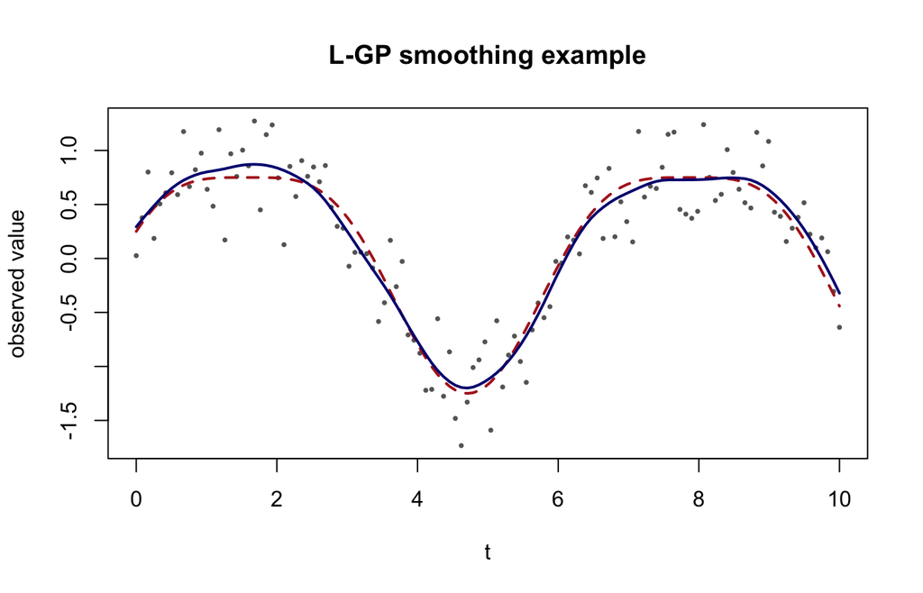

```r
plot(t, x, pch = 16, cex = 0.5, col = "grey40",
     main = "L-GP smoothing example",
     xlab = "t", ylab = "observed value")
lines(t, truth, col = "firebrick", lwd = 2, lty = 2)
lines(t, fit$posterior$mean, col = "navy", lwd = 2)
```

# Output Structure

The generator workflows return objects with class `c("list", "ebnm")`. Common components include:

- `posterior`: posterior means, variances, and second moments.
- `fitted_g`: the fitted prior-family parameterization.
- `fitted_beta`: the fitted or fixed global coefficient(s).
- `g_init`: the initialization used for the family.
- `log_likelihood`: the main model-comparison quantity returned by the fitter.

The exact additional components depend on the backend. For example, the Matern fit exposes the mesh and a latent spatial-field summary; `inla_result` is `NULL` in exact mode and stores the INLA fit object in `pc.penalty` mode.

`eb_smoother()` instead returns an object with class `c("eb_smoother_fit", "list")`. In addition to the stored posterior summaries, these fits expose:

- `fitted_noise_sd` for the learned-noise workflow,
- `family`, `backend`, and `noise_mode` metadata,
- `fitted_g` and `fitted_beta`, and
- compact `print()` / `summary()` methods for collaborator-facing inspection.